# FML Assignment 6

Pooja Babu

2025-04-14

In this assignment, we analyzed a wine dataset using hierarchical as well as non-hierarchical clustering methods. Following data normalization, AGNES and DIANA were both applied. AGNES (Ward linkage) thus produced more cohesive clusters due to its higher agglomerative coefficient. We have calculated and then visualized median values with Alcohol, Ash, also Color Intensity by categorical groupings in order to uncover patterns within wine characteristics. In addition, K-Means and DBSCAN were explored as other methods for clustering. K-Means produced defined clusters with a decent silhouette score, while DBSCAN found certain noise points but was subject to parameter tuning. AGNES and K-Means were generally most effective for this data.

```r
#Loading the required libraries
library(e1071)
library(readr)
library(dplyr)
library(tinytex)
library(cluster)
library(dbscan)
library(fpc)
```

```r
library(ggplot2)
library(gridExtra)
library(factoextra)
# Importing the dataset.
wine.data <- read_csv("C:/Users/pooja/Downloads/Wine-clustering-HC.csv")
#Checking for missing values
sum(is.na(wine.data))
```

```
## [1] 0
```

```r
# Checking the dimensions of the dataset
dim(wine.data)
```

```
## [1] 178  16
```

```r
# Checking the key statistics of the dataset
summary(wine.data)
```

```
##     Alcohol        Malic_Acid         Ash         Ash_Alcanity
##  Min.   :11.03   Min.   :0.740   Min.   :1.360   Min.   :10.60
##  1st Qu.:12.36   1st Qu.:1.603   1st Qu.:2.210   1st Qu.:17.20
##  Median :13.05   Median :1.865   Median :2.360   Median :19.50
##  Mean   :13.00   Mean   :2.336   Mean   :2.367   Mean   :19.49
##  3rd Qu.:13.68   3rd Qu.:3.083   3rd Qu.:2.558   3rd Qu.:21.50
##  Max.   :14.83   Max.   :5.800   Max.   :3.230   Max.   :30.00
##    Magnesium      Total_Phenols     Flavanoids    Nonflavanoid_Phenols
##  Min.   : 70.00   Min.   :0.980   Min.   :0.340   Min.   :0.1300
##  1st Qu.: 88.00   1st Qu.:1.742   1st Qu.:1.205   1st Qu.:0.2700
##  Median : 98.00   Median :2.355   Median :2.135   Median :0.3400
##  Mean   : 99.74   Mean   :2.295   Mean   :2.029   Mean   :0.3619
##  3rd Qu.:107.00   3rd Qu.:2.800   3rd Qu.:2.875   3rd Qu.:0.4375
##  Max.   :162.00   Max.   :3.880   Max.   :5.080   Max.   :0.6600
##  Proanthocyanins Color_Intensity       Hue             OD280
##  Min.   :0.410   Min.   : 1.280   Min.   :0.4800   Min.   :1.270
##  1st Qu.:1.250   1st Qu.: 3.220   1st Qu.:0.7825   1st Qu.:1.938
##  Median :1.555   Median : 4.690   Median :0.9650   Median :2.780
##  Mean   :1.591   Mean   : 5.058   Mean   :0.9574   Mean   :2.612
##  3rd Qu.:1.950   3rd Qu.: 6.200   3rd Qu.:1.1200   3rd Qu.:3.170
##  Max.   :3.580   Max.   :13.000   Max.   :1.7100   Max.   :4.000
##     Proline       Alcohol_Level      Ash_Content        Color_Intensity_Group
##  Min.   : 278.0   Length:178         Length:178         Length:178
##  1st Qu.: 500.5   Class :character   Class :character   Class :character
##  Median : 673.5   Mode  :character   Mode  :character   Mode  :character
##  Mean   : 746.9
##  3rd Qu.: 985.0
##  Max.   :1680.0
```

```r
# Checking the structure of the dataset.
str(wine.data)
```

```
## spc_tbl_ [178 × 16] (S3: spec_tbl_df/tbl_df/tbl/data.frame)
##  $ Alcohol              : num [1:178] 14.2 13.2 13.2 14.4 13.2 ...
##  $ Malic_Acid           : num [1:178] 1.71 1.78 2.36 1.95 2.59 1.76 1.87 2.15 1.64 1.35 ...
##  $ Ash                  : num [1:178] 2.43 2.14 2.67 2.5 2.87 2.45 2.45 2.61 2.17 2.27 ...
##  $ Ash_Alcanity         : num [1:178] 15.6 11.2 18.6 16.8 21 15.2 14.6 17.6 14 16 ...
##  $ Magnesium            : num [1:178] 127 100 101 113 118 112 96 121 97 98 ...
##  $ Total_Phenols        : num [1:178] 2.8 2.65 2.8 3.85 2.8 3.27 2.5 2.6 2.8 2.98 ...
##  $ Flavanoids           : num [1:178] 3.06 2.76 3.24 3.49 2.69 3.39 2.52 2.51 2.98 3.15 ...
##  $ Nonflavanoid_Phenols : num [1:178] 0.28 0.26 0.3 0.24 0.39 0.34 0.3 0.31 0.29 0.22 ...
##  $ Proanthocyanins      : num [1:178] 2.29 1.28 2.81 2.18 1.82 1.97 1.98 1.25 1.98 1.85 ...
##  $ Color_Intensity      : num [1:178] 5.64 4.38 5.68 7.8 4.32 6.75 5.25 5.05 5.2 7.22 ...
##  $ Hue                  : num [1:178] 1.04 1.05 1.03 0.86 1.04 1.05 1.02 1.06 1.08 1.01 ...
##  $ OD280                : num [1:178] 3.92 3.4 3.17 3.45 2.93 2.85 3.58 3.58 2.85 3.55 ...
##  $ Proline              : num [1:178] 1065 1050 1185 1480 735 ...
##  $ Alcohol_Level        : chr [1:178] "High" "Medium" "Medium" "High" ...
##  $ Ash_Content          : chr [1:178] "Moderate" "Low" "High" "Moderate" ...
##  $ Color_Intensity_Group: chr [1:178] "Moderate" "Moderate" "Moderate" "Dark" ...
##  - attr(*, "spec")=
##   .. cols(
##   ..   Alcohol = col_double(),
##   ..   Malic_Acid = col_double(),
##   ..   Ash = col_double(),
##   ..   Ash_Alcanity = col_double(),
##   ..   Magnesium = col_double(),
##   ..   Total_Phenols = col_double(),
##   ..   Flavanoids = col_double(),
##   ..   Nonflavanoid_Phenols = col_double(),
##   ..   Proanthocyanins = col_double(),
##   ..   Color_Intensity = col_double(),
##   ..   Hue = col_double(),
##   ..   OD280 = col_double(),
##   ..   Proline = col_double(),
##   ..   Alcohol_Level = col_character(),
##   ..   Ash_Content = col_character(),
##   ..   Color_Intensity_Group = col_character()
##   .. )
##  - attr(*, "problems")=<externalptr>
```

## Question 1.A. Use the wine dataset to perform hierarchical clustering using both AGNES and

DIANA.

```r
# Normalizing the dataset excluding the categorical variables.
num.only <-scale(wine.data %>% select(-Alcohol_Level, -Ash_Content, -Color_Intensity_Group))
```

```r
# Using AGNES method comparing the single, complete, average, and ward linkage

AC.single <-agnes(num.only,method = "single")
print(paste("Single Linkage AC:",AC.single$ac))
```

```
## [1] "Single Linkage AC: 0.537912775169696"
```

```r
AC.complete <-agnes(num.only,method = "complete")
print(paste("Complete Linkage AC:",AC.complete$ac))
```

```
## [1] "Complete Linkage AC: 0.815931026108809"
```

```r
AC.avg <-agnes(num.only,method = "average")
print(paste("Average Linkage AC:",AC.avg$ac))
```

```
## [1] "Average Linkage AC: 0.700696409602511"
```

```r
AC.ward <- agnes(num.only, method = "ward")
print(paste("Ward Linkage AC:",AC.ward$ac))
```

```
## [1] "Ward Linkage AC: 0.941917204381566"
```

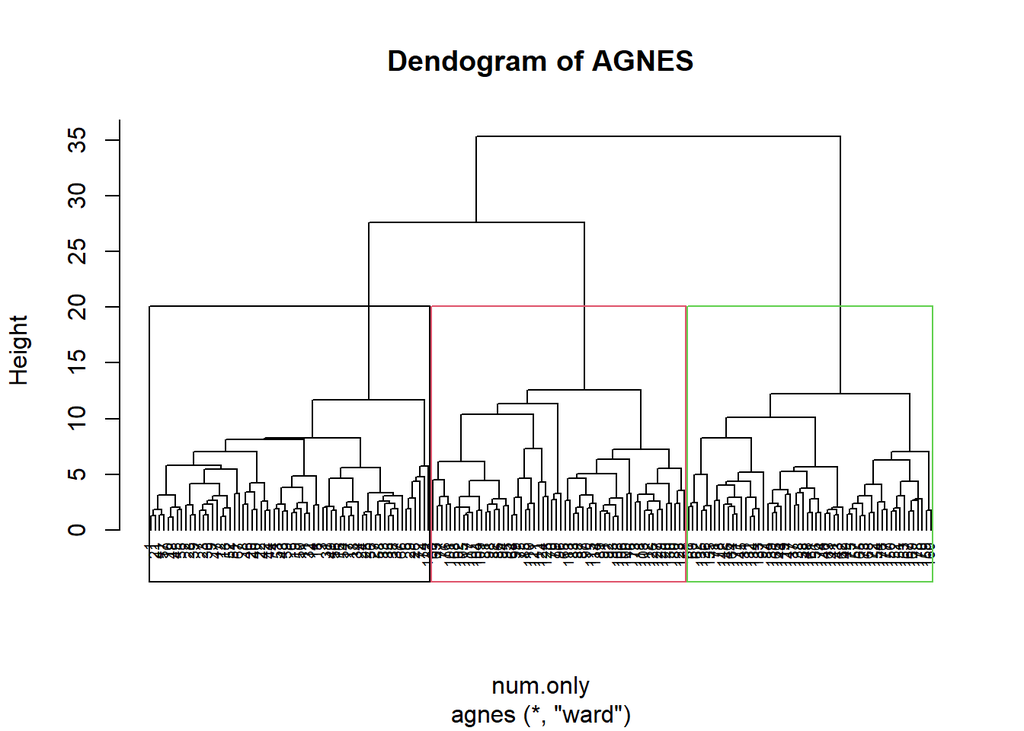

```r
# Plotting dendogram using the highest AC ( Ward Linkage )
pltree(AC.ward,cex = 0.6,hang = -1, main = "Dendogram of AGNES")
rect.hclust(as.hclust(AC.ward), k = 3, border = 1:3)
```

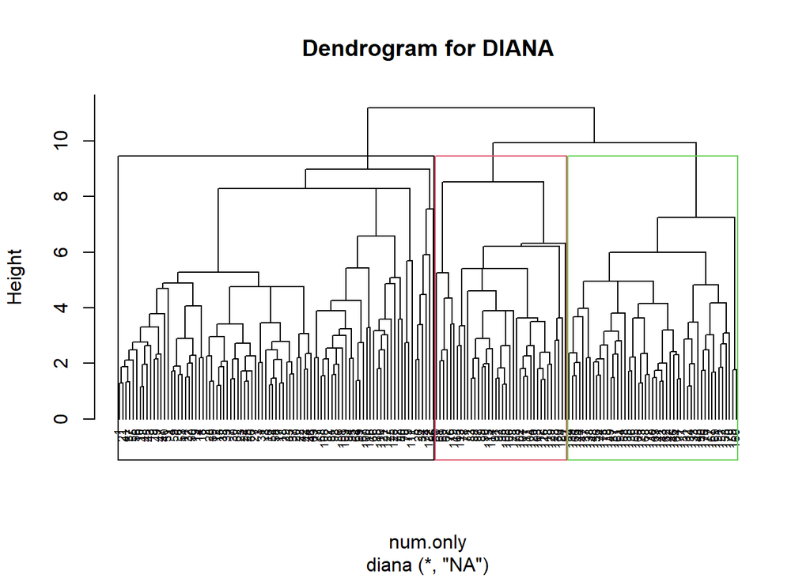

```r
# Using DIANA method
wine.DIANA <- diana(num.only)

# Plotting dendogram for DIANA method
pltree(wine.DIANA, main = "Dendrogram for DIANA", cex = 0.6, hang = -1)
rect.hclust(as.hclust(wine.DIANA), k = 3, border = 1:3)
```

Interpretation :

In this analysis, both AGNES (agglomerative) and DIANA (divisive) hierarchical clustering methods were used on the wine dataset to assess its basic organization. Among many linkage methods tested in AGNES, the Ward linkage technique yielded the highest agglomerative coefficient, indicating the most cohesive clustering. As a result, the Ward method was selected as being for further analysis. Dendrograms have been generated for both AGNES and DIANA, in order to highlight a 3-cluster solution through visual separation. Upon comparison, the AGNES dendrogram displayed more distinct and well-separated clusters, to suggest clearer boundaries between groups. On the contrary, the DIANA dendrogram produced a few less defined separations. The clusters were appearing a bit more overlapped and imbalanced. This suggests AGNES with Ward linkage is suitable for this dataset, for providing stronger inter-cluster separation and compact intra-cluster similarity. The hierarchical structure visualized through AGNES supports a generally interpretable clustering outcome, making it a relatively better choice for segmenting the wine data. In general, the results do serve to reinforce how AGNES is effective with Ward linkage over DIANA as it reveals meaningful clusters in the dataset.

## Question 1.B Compare the agglomerative coefficient (AC) of AGNES with the divisive

coefficient (DC) of DIANA. Which method provides a more cohesive clustering structure based on the coefficients?

```r
# Comparing the  coefficients of AGNES and DIANA.
AC.ward$ac
```

```
## [1] 0.9419172
```

```r
wine.DIANA$dc
```

```
## [1] 0.8000096
```

Interpretation :

Here, we calculated also compared the clustering performance of AGNES and DIANA using their respective coefficients. The agglomerative coefficient (AC) value for AGNES was 0.9419172, while the divisive coefficient (DC) value for DIANA was 0.8000096. Both coefficients lie in the range from 0 to 1, in which values that are closer to 1 indicate a stronger and more cohesive clustering structure. The higher coefficient does suggest that such clustering method better captures the natural structure within the data. According to these results, AGNES outperformed DIANA regarding cluster cohesion within the wine dataset. A higher AC value, in some instances, for AGNES implies that its clusters, to some degree, are more compact and well-separated in comparison to those produced via DIANA. This quantitative finding aligns to the dendrogram visualizations, in which AGNES showed more clear, more distinct clusters. AGNES is therefore deemed more appropriate for this dataset when using Ward linkage, because it is effective. This provides a more reliable clustering outcome that is interpretable. That comparison seems to support that conclusion, which indicates the agglomerative approach is better suited to the wine data than is the divisive method.

## Question.2.A For each of the categorical variables, namely, Alcohol_Level, Ash_Content, Color_Intensity_Group, calculate the median of the corresponding numeric variable (Alcohol, Ash, Color_Intensity).

```r
# Calculating medians for Alchohol level
alc.median<- wine.data %>%
  group_by(Alcohol_Level) %>%
  summarize(median_alcohol = median(Alcohol))

alc.median
```

```
## # A tibble: 3 × 2
##   Alcohol_Level median_alcohol
##   <chr>                  <dbl>
## 1 High                    13.9
## 2 Low                     12.1
## 3 Medium                  13.0
```

```r
# Calculating medians for Ash content
ash.median<- wine.data %>%
  group_by(Ash_Content) %>%
  summarize(median_ash = median(Ash))

ash.median
```

```
## # A tibble: 3 × 2
##   Ash_Content median_ash
##   <chr>            <dbl>
## 1 High              2.70
## 2 Low               2.17
## 3 Moderate          2.4
```

```r
# Calculating medians for Color Intensity group
col.median<- wine.data%>%
  group_by(Color_Intensity_Group)%>%
  summarize(median_color = median(Color_Intensity))

col.median
```

```
## # A tibble: 3 × 2
##   Color_Intensity_Group median_color
##   <chr>                        <dbl>
## 1 Dark                          7.65
## 2 Light                         2.9
## 3 Moderate                      5.04
```

Interpretation :

## Question.2.B Create bar plots to visualize these median values across different levels of the

categorical variables

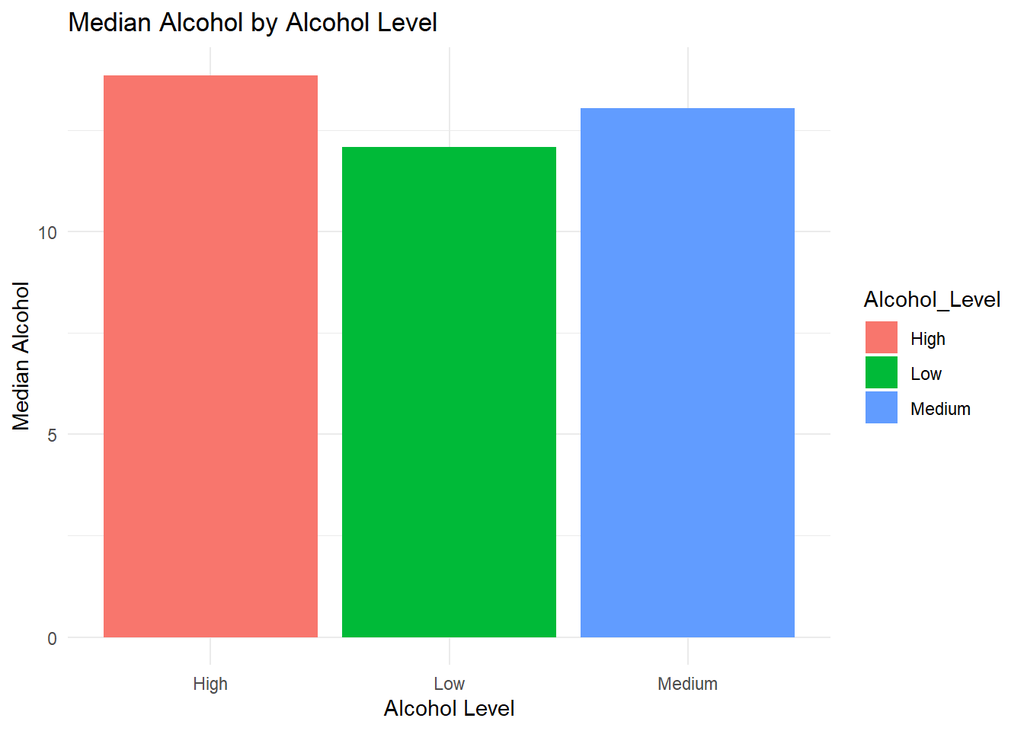

```r
# Creating a bar plot of median alcohol values
ggplot(alc.median, aes(x = Alcohol_Level, y = median_alcohol, fill = Alcohol_Level)) +
  geom_bar(stat = "identity") +
  labs(title = "Median Alcohol by Alcohol Level", x = "Alcohol Level", y = "Median Alcohol") +
  theme_minimal()
```

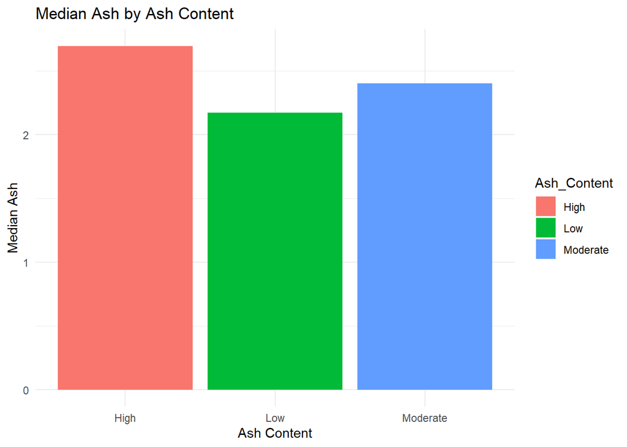

```r
# Creating a bar plot of median ash values
ggplot(ash.median, aes(x = Ash_Content, y = median_ash, fill = Ash_Content)) +
  geom_bar(stat = "identity") +
  labs(title = "Median Ash by Ash Content", x = "Ash Content", y = "Median Ash") +
  theme_minimal()
```

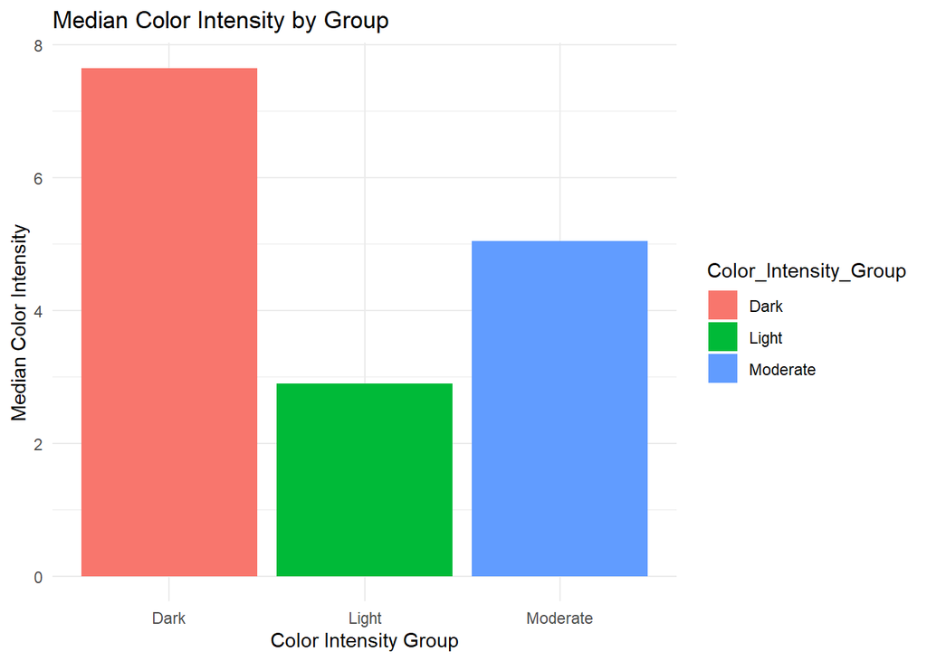

```r
# Creating a bar plot of median color intensity values
ggplot(col.median, aes(x = Color_Intensity_Group, y = median_color, fill = Color_Intensity_Group)) +
  geom_bar(stat = "identity") +
  labs(title = "Median Color Intensity by Group", x = "Color Intensity Group", y = "Median Color Intensity") +
  theme_minimal()
```

## Question.2.C. What do the median values suggest about the distribution of the numeric variables across the different categories? What insights can you derive regarding the characteristics of the wines?

Interpretation :

Insights :

The upward trends throughout each of the three categorical features imply correlations exist. Wines that possess higher alcohol content might also show elevated ash levels with darker color intensity, pointing in the direction of a potential cluster among premium and full-bodied wines. The features in this interrelationship could be used in predictive modeling, in quality assessment, or in wine classification. Additionally, the clear separation of categories, across all three plots, does confirm that these variables had been mindfully grouped, as well as being meaningful in the comprehension of wine characteristics. These understandings support further investigation into multivariate relationships. For deeper analysis, these features could be integrated into machine learning or clustering models.

## Q.3.A. Considering the results from AGNES and DIANA, which hierarchical clustering

technique is more appropriate for analyzing the wine dataset? Compare the results obtained from AGNES and DIANA, focusing on the number of clusters formed and the quality of separation. Discuss any meaningful patterns or insights observed in the clusters.

```r
# AGNES clusters through Ward linkage
print(paste("Best AGNES AC (Ward):", round(AC.ward$ac, 4)))
```

```
## [1] "Best AGNES AC (Ward): 0.9419"
```

```r
# DIANA clusters
print(paste("DIANA DC:", round(wine.DIANA$dc, 4)))
```

```
## [1] "DIANA DC: 0.8"
```

Interpretation :

Based on the hierarchical clustering results from the wine dataset, AGNES (Agglomerative Nesting) with the Ward linkage proves to be more effective than that of DIANA (Divisive Analysis). This conclusion is supported both in quantity and in vision. For AGNES, the agglomerative coefficient (AC) came to 0.9419, and for DIANA, the divisive coefficient (DC) came to 0.8000. These coefficients denote the degree of clustering structure. They also denote its cohesiveness. A value that is closer to 1 suggests clusters being better defined. Since AGNES had a higher AC, it implies that the clusters formed by this method are more compact and better separated, indicating greater internal consistency within clusters and more clear boundaries between them.

When comparing the dendrograms generated by the two methods, the AGNES dendrogram—especially using Ward’s method—showed three distinct, as well as well-balanced, clusters with minimal overlap. The branches were equally distributed and distinctly segmented, suggesting that the wines inside each cluster share related characteristics. In contrast, the DIANA dendrogram exhibited less distinct separation, some clusters appearing imbalanced as well as overlapping, indicating the clustering structure was not as clear or reliable. This visual analysis reinforces the numerical comparison and suggests AGNES with Ward linkage completely captures the structure of the wine dataset with more accuracy.

Overall, AGNES using Ward linkage suits the wine dataset better than DIANA. It yields higher cluster cohesion based on that coefficient in addition to production of clearer visual separations and alignment well enough with the underlying distribution of dataset’s features. This method effectively identifies and segments wines into meaningful clusters. These clusters reflect differences in alcohol content, ash levels, and color intensity, making it a more reliable and perceptive technique for this type of data.

## Q.3.B. Would another clustering approach, such as K-Means or DBSCAN, be more suitable for this dataset? Explain your reasoning based on the dataset properties and clustering results.

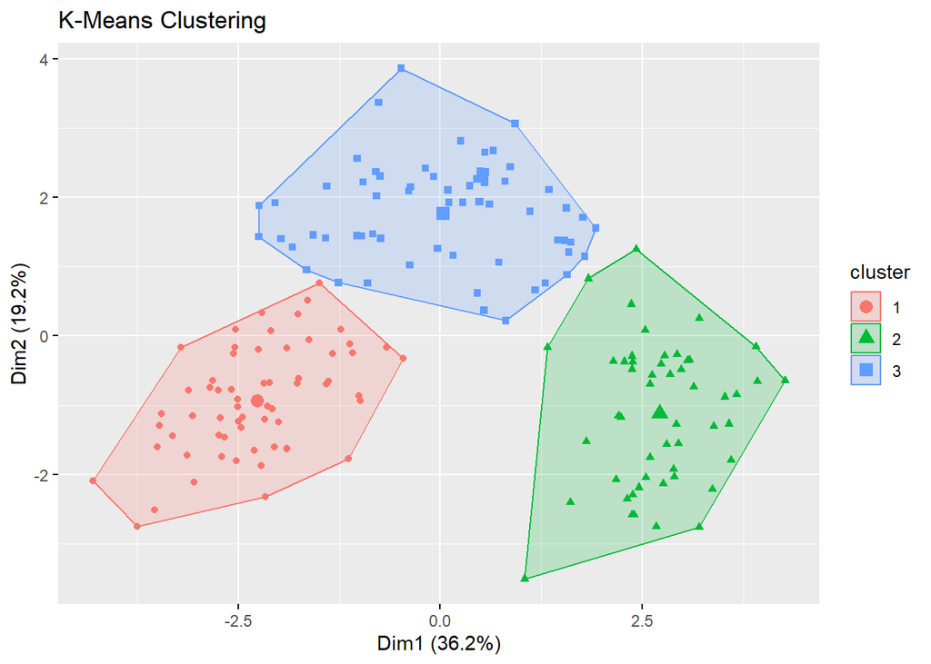

```r
# Reuse scaled data from before
set.seed(1181) #Setting seed for reproducibility


# k-Means Clustering
# Trying 3 clusters same as used above for agnes
kmeans_model <- kmeans(num.only, centers = 3, nstart = 25)
# Visualize K-Means clustering
fviz_cluster(kmeans_model, data = num.only , geom = "point", main = "K-Means Clustering")
```

```r
# Silhouette Method for K-Means Clustering
sil_kmeans <- silhouette(kmeans_model$cluster, dist(num.only))
mean(sil_kmeans[, 3])
```

```
## [1] 0.2848589
```

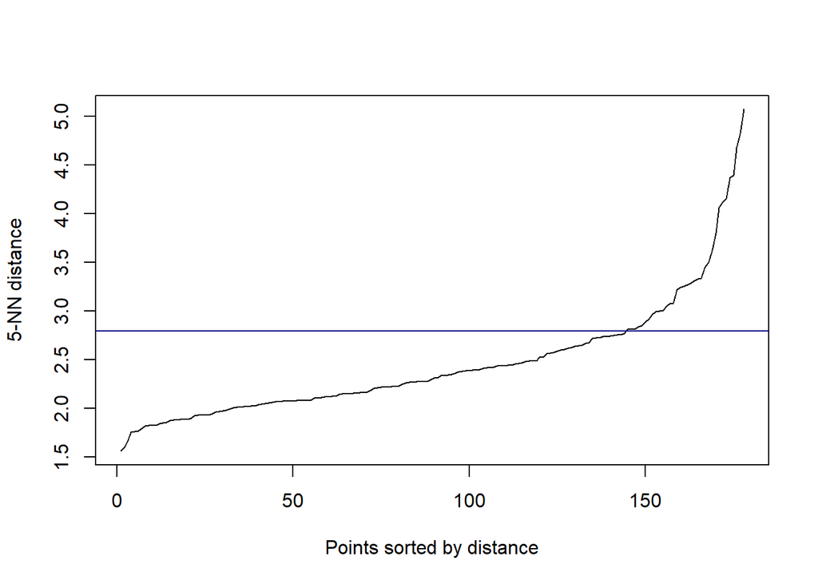

```r
#DBSCAN Clustering
#Estimate eps value visually
kNNdistplot(num.only, k = 5)
abline(h = 2.79, col = "navy") # adjust based on plot
```

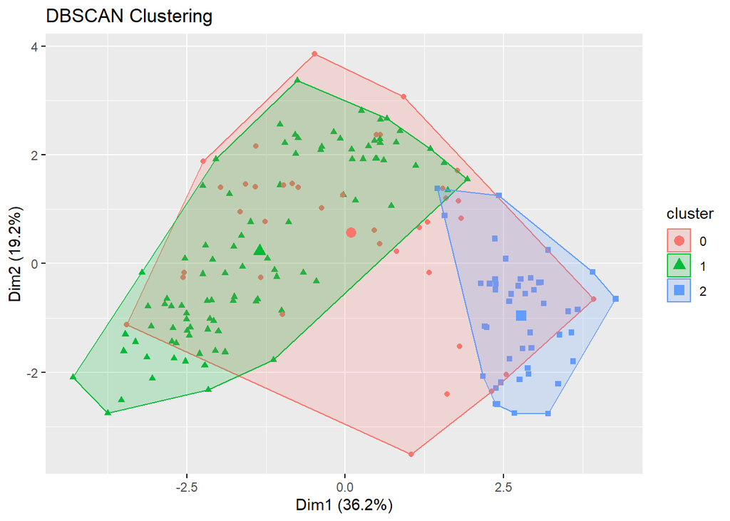

```r
# DBSCAN
dbscan_model <- fpc::dbscan(num.only, eps = 2.79,MinPts = 26)

# Visualize DBSCAN result

fviz_cluster(list(data = num.only, cluster = dbscan_model$cluster),
 geom = "point", main = "DBSCAN Clustering")
```

```r
# no. of clusters and noise points
table(dbscan_model$cluster)
```

```
##
##  0  1  2
## 38 95 45
```

Based on all the outputs as well as clusters visualized, for this dataset 4 clustering approaches have already been tried, and the results are analyzed.

K-Means clustering, in contrast, assumes clusters feature spherical shapes with fairly similar densities. In the image, the K-Means plot shows three separated compact clusters with clarity, and little overlap to no overlap. This suggests that the dataset does align rather well with the assumptions of K-Means. The boundaries between the clusters are clearly defined, and the visual result indicates that K-Means fully captures the structure of the data. Since the clusters have balance and clarity, K-Means offers the best clustering result of the four methods, with accuracy and interpretability.

In summary, while each method for clustering has strengths, K-Means seems most suitable to this dataset. It yields reasonably compact, mostly well-separated clusters mirroring the data’s fundamental structure quite effectively. Hierarchical methods such as DIANA as well as AGNES offer comprehension into cluster hierarchies but may battle with cluster definition in larger or more uniform datasets. DBSCAN is valuable even for more complex structures, but does show some overlap here. Therefore, with the basis on clustering results in addition to the apparent structure within the dataset, K-Means is a preferred approach.